# **Desafio Tecnico: Mercado Libre**

**Consignas**:

- 1) Realizar un analisis exploratorio de las publicaciones con descuento del marketplace
- 2) Armar un dataset y un modelo que permita predecir con atributos de la publicacion el valor de `sold quantity`

**Aclaracion:** En un primer momento opte armar un modelo general que permita predecir cualquier tipo de publicacion. El problema con este enfoque era que involucraba una complejidad de infraestructura y extension de tiempo que, dada la escasez, enfrente pero decidi abandonar.

```python
import math
import pandas as pd
import numpy as np
import matplotlib.pyplot as plt
import seaborn as sns
from datetime import datetime
from sklearn.pipeline import Pipeline
from sklearn.model_selection import train_test_split, KFold, cross_val_score, GridSearchCV
from sklearn.preprocessing import OneHotEncoder, LabelEncoder
from sklearn.compose import ColumnTransformer
from sklearn.feature_extraction.text import CountVectorizer
from sklearn.impute import SimpleImputer
from lightgbm import LGBMRegressor

from utils import *
```

```python
logger = logging.getLogger()
logger.setLevel(logging.INFO)
pd.set_option('display.float_format', lambda x: '%.3f' % x)
```

```python
token = get_token(APP_INFO["app_id"], APP_INFO["secret_key"], AUTH["refresh_token"])
```

```python
productos = ["notebook", "celular", "monitor", "parlante", "auriculares"]
final_df = get_dataset(productos, token)
```

```
INFO:root:Getting data for notebook
INFO:root:Getting data for celular
INFO:root:Getting data for monitor
INFO:root:Getting data for parlante
INFO:root:Getting data for auriculares
INFO:root:Filtering ids
INFO:root:Requesting ids
```

## **EDA**

```python
# Creamos las columnas con los descuentos
final_df['has_discount'] = final_df['original_price'].notnull()
final_df['discount'] = ((final_df['original_price'] - final_df['price'])/ final_df['original_price']).fillna(0)
```

Observemos la distribucion general de descuentos

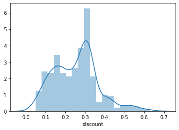

```python
sns.distplot(final_df.query('discount != 0')['discount'])
```

Podemos ver que el grueso esta entre 15% y 35%

Ahora, veamos la proporcion de productos que tienen descuentos agrupado por producto

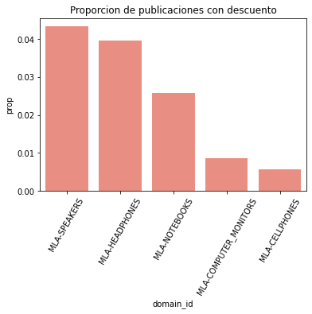

```python
props = final_df.groupby(["domain_id"])['has_discount'].value_counts(normalize=True)
props_df = props.to_frame()
props_df = props_df.rename(columns={'has_discount': 'prop'}).reset_index().sort_values('prop', ascending=False)
filter_props = props_df.query("has_discount == True")
sns.barplot(x="domain_id", y="prop", color="salmon", data=filter_props).set_title("Proporcion de publicaciones con descuento")
plt.xticks(rotation=60);
```

Veamos de los productos con descuentos, cual es el descuento promedio

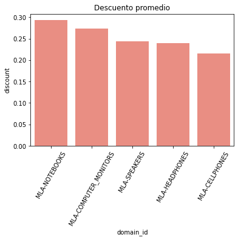

```python
discounts = final_df.query('discount != 0')
discounts = discounts.groupby('domain_id').mean().reset_index().sort_values('discount', ascending=False)
g = sns.barplot(x="domain_id", y="discount", data=discounts, color="salmon").set_title("Descuento promedio")
plt.xticks(rotation=60);
```

De todas maneras, el descuento promedio es mayor al 20% para todos los productos

Dado que el grafico anterior era una estimacion puntual, tratemos de ver la distribucion de descuentos para cada producto

En histograma

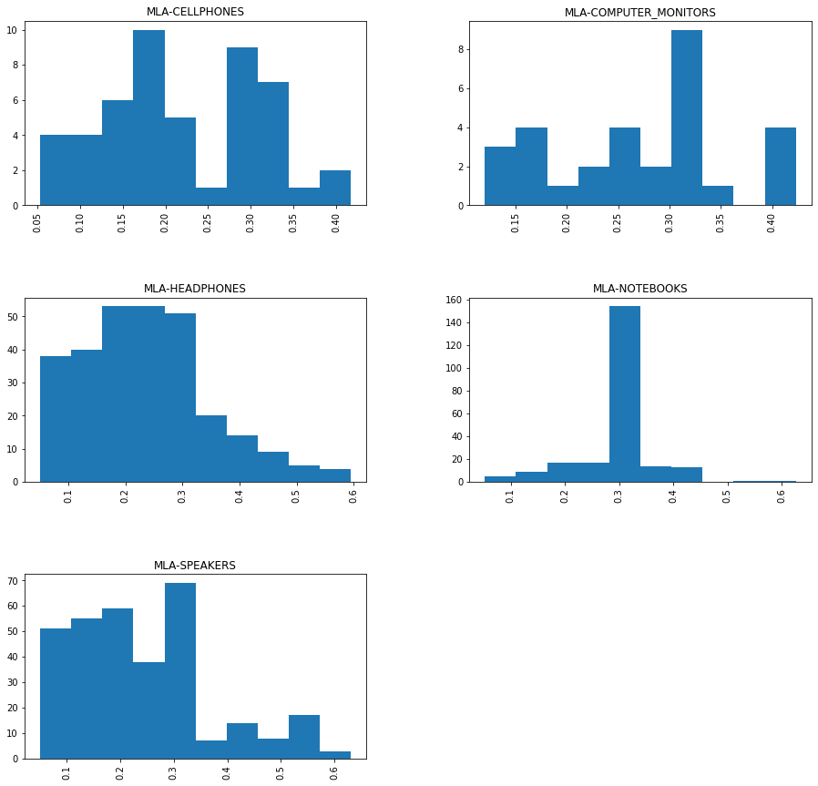

```python
final_df.query('discount != 0')['discount'].hist(by=final_df['domain_id'], figsize=(15,15));
```

En densidad:

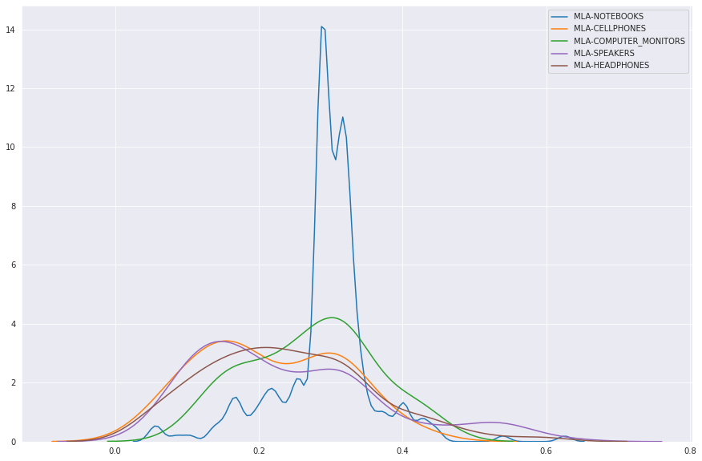

```python
plt.figure(figsize=(15,10))
sns.set_style("darkgrid")
for main_category in final_df['domain_id'].unique():
    temp = final_df.query('discount != 0')
    temp = temp.loc[temp['domain_id'] == main_category]
    sns.distplot(temp[['discount']], hist=False, label=main_category)
```

Es llamativamente interesante como la mayoria de los descuentos para las notebboks se centra en 30% mientras que el resto se distribuye mas uniformemente entren el 10% y el 35%

Veamoslo en un boxplot:

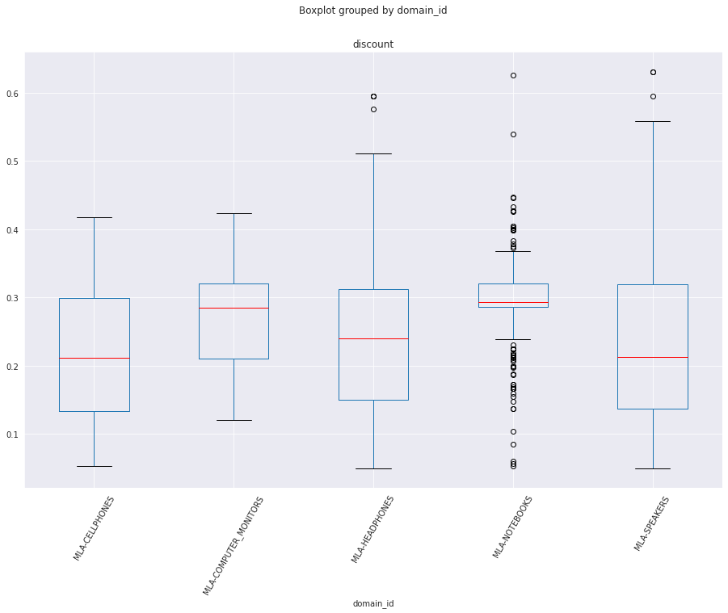

```python
final_df.query('discount != 0').boxplot(column=['discount'], by='domain_id', figsize=(15,10), rot=60, color=dict(medians='r'));
```

# **Data Wrangling**

Antes de procesar las columnas con formatos no convencionales, tratemos de limpiar un poco nuestro dataset. Se busca eliminar:

- Las features que tienen valores unicos para cada observacion
- Feature que tienen el mismo valor para todas las observaciones
- Observaciones con outliers en nuestras variables numericas

```python
final_df.columns
```

```
Index(['id', 'site_id', 'title', 'subtitle', 'seller_id', 'category_id',
       'official_store_id', 'price', 'base_price', 'original_price',
       'currency_id', 'initial_quantity', 'available_quantity',
       'sold_quantity', 'sale_terms', 'buying_mode', 'listing_type_id',
       'start_time', 'historical_start_time', 'stop_time', 'condition',
       'permalink', 'thumbnail', 'secure_thumbnail', 'pictures', 'video_id',
       'descriptions', 'accepts_mercadopago',
       'non_mercado_pago_payment_methods', 'international_delivery_mode',
       'seller_contact', 'coverage_areas', 'attributes', 'warnings',
       'listing_source', 'variations', 'status', 'sub_status', 'tags',
       'warranty', 'catalog_product_id', 'domain_id', 'parent_item_id',
       'differential_pricing', 'deal_ids', 'automatic_relist', 'date_created',
       'last_updated', 'total_listing_fee', 'health', 'catalog_listing',
       'shipping.mode', 'shipping.free_methods', 'shipping.tags',
       'shipping.dimensions', 'shipping.local_pick_up',
       'shipping.free_shipping', 'shipping.logistic_type',
       'shipping.store_pick_up', 'seller_address.city.name',
       'seller_address.state.id', 'seller_address.state.name',
       'seller_address.country.id', 'seller_address.country.name',
       'seller_address.search_location.neighborhood.id',
       'seller_address.search_location.neighborhood.name',
       'seller_address.search_location.city.id',
       'seller_address.search_location.city.name',
       'seller_address.search_location.state.id',
       'seller_address.search_location.state.name', 'seller_address.latitude',
       'seller_address.longitude', 'seller_address.id', 'geolocation.latitude',
       'geolocation.longitude', 'seller_address.city.id', 'shipping.methods',
       'message', 'error', 'cause', 'has_discount', 'discount'],
      dtype='object')
```

Por simplicidad, eliminemos las variales espaciales latitud y longitud

```python
final_df.drop(["seller_address.latitude", "seller_address.longitude", "geolocation.latitude", "geolocation.longitude"], axis=1, inplace=True)
```

Podemos ver que las variables price y base_price parecen ser iguales, veamoslo...

```python
sum(final_df['price'] != final_df['base_price'])
```

```
1
```

```python
final_df.drop("base_price", axis=1, inplace=True)
```

Entonces, nuestras variables numericas son:

- price
- original_price
- initial_quantity
- available_quantity
- sold_quantity
- discount

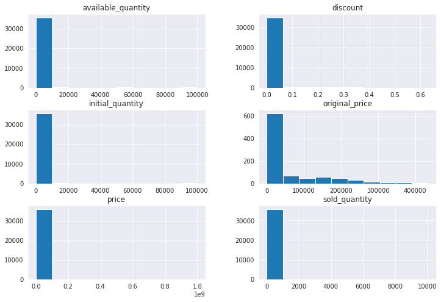

```python
numeric_features = ["price", "discount", "available_quantity", "initial_quantity", "original_price", "sold_quantity"]
final_df[numeric_features].hist(figsize=(12,8));
```

```python
final_df[numeric_features].describe()
```

|  | price | discount | available_quantity | initial_quantity | original_price | sold_quantity |
| --- | --- | --- | --- | --- | --- | --- |
| count | 35849.000 | 35850.000 | 35849.000 | 35849.000 | 918.000 | 35849.000 |
| mean | 131674.066 | 0.007 | 569.815 | 585.122 | 60732.146 | 16.106 |
| std | 5892896.035 | 0.044 | 5685.254 | 5689.345 | 87122.136 | 118.751 |
| min | 22.000 | 0.000 | 0.000 | 1.000 | 165.000 | 0.000 |
| 25% | 3199.000 | 0.000 | 1.000 | 1.000 | 5492.250 | 0.000 |
| 50% | 15650.000 | 0.000 | 3.000 | 5.000 | 16849.000 | 0.000 |
| 75% | 88990.000 | 0.000 | 10.000 | 18.000 | 83349.000 | 3.000 |
| max | 999999999.000 | 0.631 | 99999.000 | 100110.000 | 434999.000 | 10059.000 |

Bueno, tenemos valorex extremos en casi todas las categorias... arranquemos por analizar los precios

```python
final_df.query("price > 1e05")[['title', 'price']].sort_values('price', ascending=False)[:20]
```

|  | title | price |
| --- | --- | --- |
| 16454 | Celular Nuevo Con Fondo De Pantalla De Pantall... | 999999999.000 |
| 15087 | iPhone 7 - 32 Gb No Tiene Stock. | 289999999.000 |
| 17220 | ... | 250000000.000 |
| 14168 | Camperita Termica Para Perro Talle 1-5 | 222222222.000 |
| 16364 | iPhone 4s 16 Gb Mas 500$ Que Hay | 111111111.000 |
| 17156 | Huawei Y6 | 100000099.000 |
| 14328 | Samsung S8 Plus | 99999999.000 |
| 16706 | LG K4 Lte Con Detalles En Pantalla. | 99999999.000 |
| 9578 | Celular Roto Para Reparar | 80000000.000 |
| 10245 | Celular | 9954695.000 |
| 28157 | Columnas Bowers & Wilkins Modelo 802 D3 Ba-store | 5199950.000 |
| 28558 | Parlantes Elac Fs 509 | 3000000.000 |
| 28497 | Bafles Piega Classic 80.2 | 3000000.000 |
| 14790 | Sophos Sf Sw/ Virtual P/talprotect 8 Cores & 1... | 2574388.280 |
| 28454 | Dynaudio Confidence C4 Audiophile66 | 2291532.890 |
| 27115 | Bafles Kef Referemce 5 Caballito Liniers Tomam... | 2144625.000 |
| 28511 | Columnas Bowers & Wilkins B&w Modelo 804 D3 Ba... | 2099950.000 |
| 13956 | Sophos Sf Sw/ Virtual P/talprotect Plus 6 Core... | 2037296.480 |
| 27366 | Monitor Audio Pl 300 Ii Par De Bafles Linea Pl... | 1655000.000 |
| 27588 | Bafles Triangle Genese Lyrr Distribuidor Oficial | 1520000.000 |

```python
final_df = final_df[final_df['price'] < 9954695]
```

Ahora observemos las cantidades vendidas

```python
final_df[['title', 'sold_quantity', "date_created"]].sort_values('sold_quantity', ascending=False)[:20]
```

|  | title | sold_quantity | date_created |
| --- | --- | --- | --- |
| 28622 | Auriculares Bluetooth Inalambricos In Ear Con ... | 10059.000 | 2019-01-04T16:32:52.000Z |
| 28610 | Auriculares Bluetooth Celular Inalambrico Depo... | 5269.000 | 2019-05-14T22:19:18.000Z |
| 28656 | Auricular Bluetooth Vincha Micro Sd Radio Fm I... | 3601.000 | 2017-06-09T13:16:00.000Z |
| 29110 | Auricular Bluetooth Nuquero, Ideal Para Correr... | 3529.000 | 2016-06-08T17:01:03.000Z |
| 29237 | Auriculares In Ear Sony Mdr-ex15lp Fidelidad Y... | 3366.000 | 2016-04-15T18:34:50.000Z |
| 28666 | Auriculares Bluetooth Qcy T2c Tws Original 201... | 3225.000 | 2017-11-22T15:24:24.000Z |
| 28640 | Auriculares Bluetooth Inalambricos In Ear Con ... | 3127.000 | 2018-12-11T14:23:18.000Z |
| 28617 | Auriculares Bluetooth In Ear Inalámbrico Tedge | 3107.000 | 2019-06-26T21:01:03.000Z |
| 21185 | Parlante Portátil 8'' Bluetooth Recargable + M... | 2987.000 | 2019-05-09T00:48:37.000Z |
| 28620 | Auriculares In Ear Inalámbrico Bluetooth \| Tou... | 2719.000 | 2019-08-16T19:32:22.000Z |
| 34618 | Auriculares Bluetooth Deportivo Inalambricos C... | 2567.000 | 2018-01-31T23:51:12.000Z |
| 21377 | Parlante Portatil Bluetooth Bateria Interna Ra... | 2439.000 | 2016-03-14T12:06:26.000Z |
| 27631 | Parlante Bluetooth Recargable Para La Ducha Re... | 2416.000 | 2017-08-09T18:30:31.000Z |
| 28626 | Auriculares Targus Bluetooth Vincha Receptor L... | 2294.000 | 2018-12-12T21:14:30.000Z |
| 21180 | Parlante Portátil Vivitar Bluetooth Diseño + C... | 2294.000 | 2018-11-29T20:11:17.000Z |
| 24429 | Parlante Bluetooth Recargable Para La Ducha Re... | 2271.000 | 2017-09-27T13:04:53.000Z |
| 28619 | Auriculares Bluetooth I12 Táctiles Ios Android... | 2271.000 | 2019-12-17T17:13:58.000Z |
| 8959 | Celular Motorola Moto E6 Plus Special Edition ... | 2237.000 | 2019-10-10T18:27:40.000Z |
| 28625 | Auriculares Bluetooth Super Bajos Vincha - Gar... | 2164.000 | 2019-05-16T19:44:38.000Z |
| 28616 | Auricular Deportivo Inalámbrico Bluetooth 5.0 ... | 2155.000 | 2020-03-19T19:46:16.000Z |

Parecerian ser todos numeros plausibles dada la antiguedad de las publicaciones, sigamos.

Ahora observemos las cantidades en stock

```python
final_df[["title", "seller_id", "available_quantity"]].sort_values("available_quantity", ascending=False)[:100]
```

|  | title | seller_id | available_quantity |
| --- | --- | --- | --- |
| 2728 | Notebook Dell Core I5 5593 8gb 256gb Ssd + 1tb... | 31875925.000 | 99999.000 |
| 7738 | Notebook Dell Intel Core I3 12gb + Ssd 480gb G... | 31875925.000 | 99999.000 |
| 3073 | Notebook Lenovo V130 Intel Quad Core N5000 15.... | 31875925.000 | 99999.000 |
| 3778 | Notebook Gamer Lenovo Intel I5 8gb 1tb Ssd 256... | 451587084.000 | 99999.000 |
| 4412 | Notebook Dell Intel Core I3 12gb + Ssd 480gb U... | 31875925.000 | 99999.000 |
| ... | ... | ... | ... |
| 17863 | Monitor Led 19 LG Ultra Fino Vga Vesa 5ms Hd R... | 451587084.000 | 60730.000 |
| 17874 | Monitor Led 19 LG Ultra Fino Vga Vesa 5ms Hd R... | 82916233.000 | 60690.000 |
| 17832 | Monitor Led 19 LG Ultra Fino Vga Vesa 5ms Hd R... | 451587084.000 | 60651.000 |
| 63 | Notebook Hp Intel Dual Core 8gb 500g Gtia Ofic... | 82916233.000 | 60286.000 |
| 35065 | Auricular Gamer Hyperx Cloud Alpha Pc Ps4 Xbox... | 82916233.000 | 55993.000 |

100 rows × 3 columns

Ahora analizemos la variabilidad de nuestras features categoricas

```python
categorical_features = list(final_df.drop(numeric_features, axis=1).columns)
```

```python
uniques ={}
for col in categorical_features:
    uniques[col] = final_df[col].apply(str).nunique() / len(final_df)
```

Empecemos viendo las que serian unicas por publicacion

```python
sorted(uniques.items(), key=lambda x: x[1], reverse=True)[:15]
```

```
[('id', 0.9831189486313793),
 ('permalink', 0.9831189486313793),
 ('descriptions', 0.9593459638940819),
 ('pictures', 0.9409023689277044),
 ('thumbnail', 0.9308853483635146),
 ('secure_thumbnail', 0.9308853483635146),
 ('last_updated', 0.9247746867937163),
 ('title', 0.9004994558999972),
 ('date_created', 0.880828148106811),
 ('historical_start_time', 0.8795167275872653),
 ('start_time', 0.8780378916822456),
 ('attributes', 0.8632774351962945),
 ('variations', 0.7636094757108178),
 ('stop_time', 0.3056446887468958),
 ('seller_id', 0.29827841178604314)]
```

Aca aparecen muchas de las variables unicas (id, permalink, descriptions, pictures, thumbnail, secure_thumbnail) que considero hay que eliminar, pero tambien una de las variables que en mi opinion, mas importa para predecir la cantidad de articulos vendidos, date_created. Veamos si start_time, historical_start_time y date_created son iguales

```python
final_df.drop(["id", "permalink", "thumbnail", "secure_thumbnail", "descriptions", "pictures"], axis=1, inplace=True)
```

```python
final_df[final_df['start_time'] != final_df['date_created']][['start_time', "date_created", "historical_start_time"]]
```

|  | start_time | date_created | historical_start_time |
| --- | --- | --- | --- |
| 5 | 2020-03-18T14:58:00.000Z | 2020-03-18T14:58:01.000Z | 2020-03-18T14:58:00.000Z |
| 7 | 2018-12-03T14:39:20.000Z | 2018-12-03T14:39:21.000Z | 2018-05-08T19:19:35.000Z |
| 13 | 2020-06-05T13:30:03.000Z | 2020-06-05T13:30:04.000Z | 2020-06-05T13:30:03.000Z |
| 15 | 2019-04-04T14:26:29.000Z | 2019-04-04T14:26:30.000Z | 2019-04-04T14:26:29.000Z |
| 16 | 2020-04-21T14:44:53.000Z | 2020-04-21T14:44:54.000Z | 2020-04-21T14:44:53.000Z |
| ... | ... | ... | ... |
| 35832 | 2017-04-18T14:22:17.000Z | 2017-04-18T14:22:18.000Z | 2017-04-18T14:22:17.000Z |
| 35838 | 2018-05-21T17:07:11.000Z | 2018-05-21T17:07:12.000Z | 2018-05-21T17:07:11.000Z |
| 35840 | 2019-11-04T14:41:02.000Z | 2019-11-04T14:41:03.000Z | 2019-11-04T14:41:02.000Z |
| 35841 | 2019-10-15T16:10:13.000Z | 2019-10-15T16:10:14.000Z | 2019-10-15T16:10:13.000Z |
| 35844 | 2018-09-19T19:13:20.000Z | 2018-09-19T19:13:21.000Z | 2018-09-19T19:13:20.000Z |

8541 rows × 3 columns

```python
final_df.drop(['start_time', "historical_start_time"], axis=1, inplace=True)
```

Y ahora transformemos un poco las columnas que tienen fechas

```python
final_df['days_old'] = (pd.Timestamp(datetime.utcnow(), tz="UTC") - pd.to_datetime(final_df['date_created'])).dt.days
final_df['days_remaining'] = (pd.to_datetime(final_df['stop_time']) - pd.Timestamp(datetime.utcnow(), tz="UTC")).dt.days
final_df['days_from_update'] = (pd.Timestamp(datetime.utcnow(), tz="UTC") - pd.to_datetime(final_df['last_updated'])).dt.days

final_df.drop(["date_created", "stop_time", "last_updated"], axis=1, inplace=True)
```

Ahora observemos si hay variables que tienen valores unicos

```python
sorted(uniques.items(), key=lambda x: x[1])[:20]
```

```
[('site_id', 2.7902564245654176e-05),
 ('subtitle', 2.7902564245654176e-05),
 ('currency_id', 2.7902564245654176e-05),
 ('buying_mode', 2.7902564245654176e-05),
 ('accepts_mercadopago', 2.7902564245654176e-05),
 ('international_delivery_mode', 2.7902564245654176e-05),
 ('seller_contact', 2.7902564245654176e-05),
 ('coverage_areas', 2.7902564245654176e-05),
 ('warnings', 2.7902564245654176e-05),
 ('listing_source', 2.7902564245654176e-05),
 ('differential_pricing', 2.7902564245654176e-05),
 ('automatic_relist', 2.7902564245654176e-05),
 ('total_listing_fee', 2.7902564245654176e-05),
 ('catalog_listing', 2.7902564245654176e-05),
 ('seller_address.country.id', 2.7902564245654176e-05),
 ('seller_address.country.name', 2.7902564245654176e-05),
 ('message', 2.7902564245654176e-05),
 ('error', 2.7902564245654176e-05),
 ('cause', 2.7902564245654176e-05),
 ('shipping.local_pick_up', 5.580512849130835e-05)]
```

Las variables cuyo valor es 2.79..e-05 tienen un solo valor. Eliminsemoslas dado que no aportan ningun tipo de informacion

```python
keys = [key for key, value in sorted(uniques.items(), key=lambda x: x[1])[:17]]
```

```python
final_df.drop(keys, axis=1, inplace = True)
```

Ahora, transformemos y adaptemos un poco las variables que tienen texto adentro como por ejemplo el titulo del la publicacion y la ciudad del vendedor

Para el titulo, quedemosnos pasemos todo a minusculas, eliminemos whitespaces y quedemosnos solo con las primeras dos palabras que usualmente tienen el nombre del producto y su marca

```python
def transform_title(x):
    words = x.strip().lower().split(" ")[:2]
    parsed_words = " ".join(words)
    return parsed_words

final_df.loc[:, 'title'] = final_df["title"].apply(transform_title)
```

Me parece redundante tener 2 variables para decir lo mismo, asi que voy a optar por sacar o el id o el city name

```python
final_df[[col for col in final_df if col.startswith("seller_address")]].head()
```

|  | seller_address.city.name | seller_address.state.id | seller_address.state.name | seller_address.search_location.neighborhood.id | seller_address.search_location.neighborhood.name | seller_address.search_location.city.id | seller_address.search_location.city.name | seller_address.search_location.state.id | seller_address.search_location.state.name | seller_address.id | seller_address.city.id |
| --- | --- | --- | --- | --- | --- | --- | --- | --- | --- | --- | --- |
| 0 | Capital Federal | AR-C | Capital Federal | TUxBQk1PTjE2OTBa | Monte Castro | TUxBQ0NBUGZlZG1sYQ | Capital Federal | TUxBUENBUGw3M2E1 | Capital Federal | 275413826.000 | NaN |
| 1 | Capital Federal | AR-C | Capital Federal | TUxBQlZJTDYzNzZa | Villa Devoto | TUxBQ0NBUGZlZG1sYQ | Capital Federal | TUxBUENBUGw3M2E1 | Capital Federal | 88719219.000 | NaN |
| 2 | Capital Federal | AR-C | Capital Federal | TUxBQk1PTjE2OTBa | Monte Castro | TUxBQ0NBUGZlZG1sYQ | Capital Federal | TUxBUENBUGw3M2E1 | Capital Federal | 275413826.000 | NaN |
| 3 | Parque Patricios | AR-C | Capital Federal | TUxBQlBBUjYwMzZa | Parque Patricios | TUxBQ0NBUGZlZG1sYQ | Capital Federal | TUxBUENBUGw3M2E1 | Capital Federal | 282172857.000 | TUxBQlBBUjYwMzZa |
| 4 | Villa Urquiza | AR-C | Capital Federal | TUxBQlZJTDcwOTla | Villa Urquiza | TUxBQ0NBUGZlZG1sYQ | Capital Federal | TUxBUENBUGw3M2E1 | Capital Federal | 1021092248.000 | NaN |

```python
final_df[[col for col in final_df if col.startswith("seller_address")]].nunique()
```

```
seller_address.city.name                             1868
seller_address.state.id                                24
seller_address.state.name                              24
seller_address.search_location.neighborhood.id        642
seller_address.search_location.neighborhood.name      595
seller_address.search_location.city.id                352
seller_address.search_location.city.name              318
seller_address.search_location.state.id                28
seller_address.search_location.state.name              28
seller_address.id                                   10690
seller_address.city.id                                240
dtype: int64
```

Parece ser que:

- Para la ciudad, el nombre tiene mas informacion
- Para la provincia, es indistinto
- Para el barrio del search location el id es mas representativo
- Para la ciudad del search location el id es mas representativo
- Para la provincia del seach location, es indistinto

```python
unwanted_seller = ["seller_address.city.id", "seller_address.state.name", "seller_address.search_location.neighborhood.name",
                   "seller_address.search_location.city.name", "seller_address.search_location.state.name"]
final_df.drop(unwanted_seller, axis=1, inplace = True)
```

La unica coumna con nombre que nos quedo es para la ciudad del vendedor, pasemosla toda a minuscula y eliminemos whitespaces

```python
final_df.loc[:, 'seller_address.city.name'] = final_df['seller_address.city.name'].apply(lambda x: x.lower().strip())
```

Procesemos la informacion que esta adentro de tags

```python
final_df["tags"] = final_df["tags"].apply(lambda x: " ".join(x)).apply(lambda x: x.replace("-", "_"))
cvect = CountVectorizer()
tags = cvect.fit_transform(final_df["tags"]).toarray()
for i, col in enumerate(cvect.get_feature_names()):
    final_df[col] = tags[:, i]
final_df.drop('tags', axis=1, inplace=True)
```

Obtengamos los atributos espeificos de la publicacion. Para esto, voy a extraer del diccionario el ID del atributo como su valor. Elijo el value_name y no el value_id por azar, me parecia mas intuitvo para entender y ver la importancia de la feature dado que los puedo asociar

```python
attrs_df = pd.json_normalize(final_df["attributes"].apply(lambda lista: {d["id"]: d["value_name"] for d in lista}))
```

```python
dataset = pd.concat([final_df, attrs_df], axis=1)
dataset.drop("attributes", axis=1, inplace=True)
```

Un **dato de color** que me hizo **perder unas cuantas horas.....**

```python
final_df.shape
```

```
(35839, 64)
```

```python
attrs_df.shape
```

```
(35839, 576)
```

```python
dataset.shape
```

```
(35850, 639)
```

```python
dataset = dataset[~dataset["sold_quantity"].isna()]
```

```python
dataset.shape
```

```
(35839, 639)
```

```python
dataset.to_csv("dataset.csv", index=None)
#dataset = pd.read_csv("dataset.csv")
```

## **Estimador**

Separamos nuestras variables, hagamos una pequeña prueba para ver si tomando logaritmos mejoramos el fit del modelo.

```python
y = dataset['sold_quantity']
y_log = np.log(dataset['sold_quantity'] + 1)
X = dataset.drop('sold_quantity', axis=1)
```

Redefinimos nuestras features numericas y categoricas y transformamos el tipo para asegurarnos de no tener errores

```python
numeric_features = ["price", "discount", "available_quantity", "initial_quantity",
                    "original_price", "days_old", "days_remaining", "days_from_update"]
X.loc[:, numeric_features] = X[numeric_features].fillna(0)
X[numeric_features] = X[numeric_features].applymap(np.float)
categorical_features = list(X.drop(numeric_features, axis=1).columns)
X.loc[:, categorical_features] = X[categorical_features].fillna("__")
X[categorical_features] = X[categorical_features].applymap(str)
```

Hagamos la prueba de la transformacion logaritimica usando nuestras variables numericas como predictores.

```python
X_train, X_test, y_train, y_test = train_test_split(X[numeric_features], y)
```

```python
params = dict(n_estimators=[800, 1000],
              learning_rate=[0.05, 0.1],
              num_leaves=[20, 30])
estimator = GridSearchCV(
        LGBMRegressor(n_jobs=-1),
        params,
        cv=5,
        n_jobs=-1,
        scoring="r2",
    )
model = estimator.fit(X_train, y_train)
```

```python
model.best_params_
```

```
{'learning_rate': 0.1, 'n_estimators': 1000, 'num_leaves': 20}
```

```python
cv = KFold(n_splits=5)
scores = cross_val_score(model, X_test, y_test, cv = cv, scoring='r2')
```

```python
scores.mean()
```

```
0.8772411823415514
```

Pareceria funcionar bastante bien, probemos tomando el logaritmo

```python
X_train, X_test, y_train, y_test = train_test_split(X[numeric_features], y_log)
```

```python
model.fit(X_train, y_train)
```

```
GridSearchCV(cv=5, error_score=nan,
             estimator=LGBMRegressor(boosting_type='gbdt', class_weight=None,
                                     colsample_bytree=1.0,
                                     importance_type='split', learning_rate=0.1,
                                     max_depth=-1, min_child_samples=20,
                                     min_child_weight=0.001, min_split_gain=0.0,
                                     n_estimators=100, n_jobs=-1, num_leaves=31,
                                     objective=None, random_state=None,
                                     reg_alpha=0.0, reg_lambda=0.0, silent=True,
                                     subsample=1.0, subsample_for_bin=200000,
                                     subsample_freq=0),
             iid='deprecated', n_jobs=-1,
             param_grid={'learning_rate': [0.05, 0.1],
                         'n_estimators': [800, 1000], 'num_leaves': [20, 30]},
             pre_dispatch='2*n_jobs', refit=True, return_train_score=False,
             scoring='r2', verbose=0)
```

```python
model.best_params_
```

```
{'learning_rate': 0.1, 'n_estimators': 1000, 'num_leaves': 30}
```

```python
cv = KFold(n_splits=5)
scores = cross_val_score(model, X_test, y_test, cv = cv, scoring='r2')
```

```python
scores.mean()
```

```
0.9459820516504198
```

Hay una mejora tomando el logaritmo. Ahora probemos un modelo con todas las features y veamos como fitea

```python
X_train, X_test, y_train, y_test = train_test_split(X, y_log)
```

```python
numeric_transformer = Pipeline(
    [('imputer', SimpleImputer(strategy='constant', fill_value=0))]
)
categorical_transformer = Pipeline([
    ('imputer', SimpleImputer(strategy='constant', fill_value='__')),
    ('onehot', OneHotEncoder(handle_unknown='ignore'))]
)
preprocessor = ColumnTransformer(
    transformers=[
        ('num', numeric_transformer, numeric_features),
        ('cat', categorical_transformer, categorical_features)])
```

```python
params = dict(n_estimators=[1000, 1500],
              learning_rate=[0.1],
              num_leaves=[30])
estimator = GridSearchCV(
        LGBMRegressor(n_jobs=-1),
        params,
        cv=5,
        n_jobs=-1,
        scoring="r2",
    )
pipe = Pipeline([('preprocessor', preprocessor), ('estimator', estimator)])
pipe.fit(X_train, y_train)
```

```
Pipeline(memory=None,
         steps=[('preprocessor',
                 ColumnTransformer(n_jobs=None, remainder='drop',
                                   sparse_threshold=0.3,
                                   transformer_weights=None,
                                   transformers=[('num',
                                                  Pipeline(memory=None,
                                                           steps=[('imputer',
                                                                   SimpleImputer(add_indicator=False,
                                                                                 copy=True,
                                                                                 fill_value=0,
                                                                                 missing_values=nan,
                                                                                 strategy='constant',
                                                                                 verbose=0))],
                                                           verbose=False),
                                                  ['price', 'discount',
                                                   'availabl...
                                                      n_jobs=-1, num_leaves=31,
                                                      objective=None,
                                                      random_state=None,
                                                      reg_alpha=0.0,
                                                      reg_lambda=0.0,
                                                      silent=True,
                                                      subsample=1.0,
                                                      subsample_for_bin=200000,
                                                      subsample_freq=0),
                              iid='deprecated', n_jobs=-1,
                              param_grid={'learning_rate': [0.1],
                                          'n_estimators': [1000, 1500],
                                          'num_leaves': [30]},
                              pre_dispatch='2*n_jobs', refit=True,
                              return_train_score=False, scoring='r2',
                              verbose=0))],
         verbose=False)
```

```python
pipe.steps[1][1].best_params_
```

```
{'learning_rate': 0.1, 'n_estimators': 1500, 'num_leaves': 30}
```

```python
cv = KFold(n_splits=5)
scores = cross_val_score(pipe, X_test, y_test, cv = cv, scoring='r2')
```

```python
scores.mean()
```

```
0.9444889256932452
```

No pareceria haber una mejora significativa por agregar la inmensa cantidad de features categoricos. De todas maneras, por todo el trabajo hecho, voy a optar por seguir el analisis de este modelo en general que, supongo, puede ser mas extensible a un predictor general de items.

```python
ohe_feature_names = pipe.steps[0][1].transformers_[1][1].steps[1][1].get_feature_names(categorical_features)
feature_importances = pipe.steps[1][1].best_estimator_.feature_importances_

cols = list(numeric_features) + list(ohe_feature_names)
f_i = list(zip(cols, feature_importances))
feat_imp = pd.DataFrame(f_i, columns=["feature_names", "importance"])
feat_imp = feat_imp.sort_values('importance', ascending=False).reset_index(drop=True)
```

```python
feat_imp[:15]
```

|  | feature_names | importance |
| --- | --- | --- |
| 0 | available_quantity | 5588 |
| 1 | initial_quantity | 5021 |
| 2 | price | 2805 |
| 3 | days_old | 2328 |
| 4 | days_remaining | 1823 |
| 5 | days_from_update | 1140 |
| 6 | dragged_bids_and_visits_0.0 | 505 |
| 7 | good_quality_thumbnail_0.0 | 419 |
| 8 | sale_terms_[{'id': 'WARRANTY_TIME', 'name': 'T... | 397 |
| 9 | DISPLAY_SIZE_15 in | 364 |
| 10 | catalog_product_id___ | 246 |
| 11 | MANUFACTURING_TIME_20 días | 224 |
| 12 | listing_type_id_gold_pro | 221 |
| 13 | loyalty_discount_eligible_0.0 | 218 |
| 14 | seller_address.search_location.neighborhood.id... | 214 |

Como esperabamos, las features numericas son las mas relevantes al momento de explicar la cantidad de ventas

```python
preds_df = X_test.copy()
preds = pipe.predict(X_test)
```

Transformamos nuestros datos, recodemos que estan en logartimos, para analizar los resultados

```python
preds_df['preds'] = np.round(np.exp(preds) - 1)
preds_df['real'] = np.exp(y_test) - 1
preds_df["error"] = np.abs(preds_df['real'] - preds_df['preds'])
```

Fijemosnos como fitea nuestro modelo

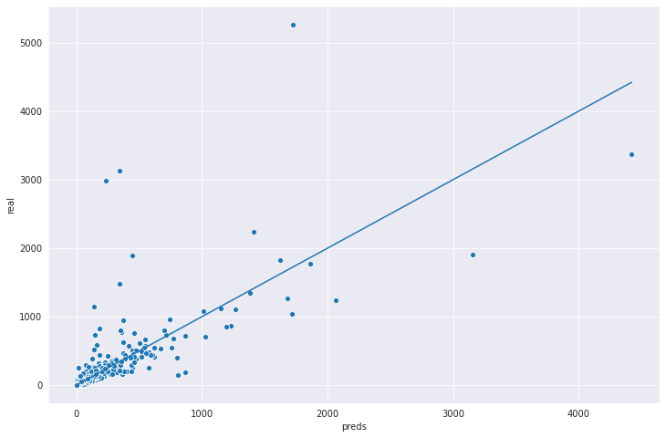

```python
plt.figure(figsize=(12,8))
sns.scatterplot(x="preds", y="real", data=preds_df)
x = [x for x in range(ceil(preds_df['preds'].max()))]
plt.plot(x, x);
```

Pareceria fittear bastante bien, veamos en valores de ventas mas chicos

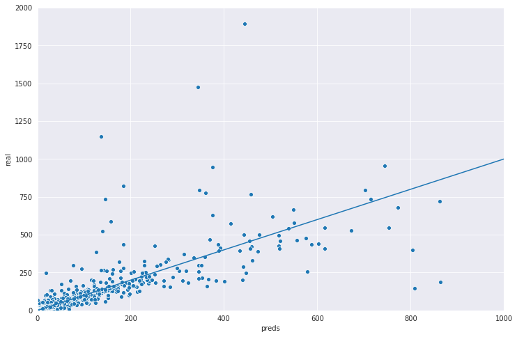

```python
plt.figure(figsize=(12,8))
sns.scatterplot(x="preds", y="real", data=preds_df)
x = [x for x in range(ceil(preds_df['preds'].max()))]
plt.plot(x, x)
plt.xlim(0, 1000)
plt.ylim(0, 2000);
```

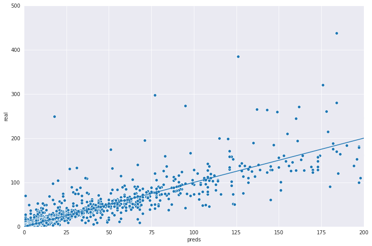

```python
plt.figure(figsize=(12,8))
sns.scatterplot(x="preds", y="real", data=preds_df)
x = [x for x in range(ceil(preds_df['preds'].max()))]
plt.plot(x, x)
plt.xlim(0, 200);
plt.ylim(0, 500);
```

Podemos ver que hay errores interesantes a analizar

Veamos si el error se asocia a algun tipo en proudcto en particular

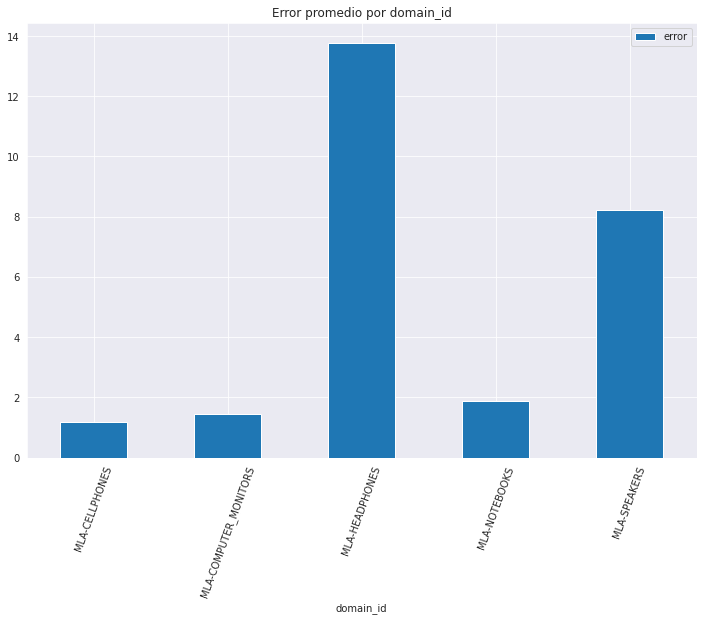

```python
preds_df.groupby("domain_id").mean().reset_index().plot.bar(x="domain_id", y='error', title='Error promedio por domain_id', figsize=(12,8))
plt.xticks(rotation=70);
```

Podemos ver que performa peor para auriculares y parlantes. Fijemosnos que paso con las observaciones que tenian errores muy grandes

```python
target_cols = ["title", "domain_id", "seller_id", "category_id"]
target_cols += feat_imp['feature_names'][:6].values.tolist()
target_cols += ["real", "error"]
```

```python
errors_df = preds_df.query("error > 200")[target_cols].sort_values("error", ascending=False)
```

```python
errors_df[:10]
```

|  | title | domain_id | seller_id | category_id | available_quantity | initial_quantity | price | days_old | days_remaining | days_from_update | real | error |
| --- | --- | --- | --- | --- | --- | --- | --- | --- | --- | --- | --- | --- |
| 28610 | auriculares bluetooth | MLA-HEADPHONES | 4808670.0 | MLA3518 | 468.000 | 5737.000 | 599.000 | 405.000 | 6896.000 | 0.000 | 5269.000 | 3547.000 |
| 28640 | auriculares bluetooth | MLA-HEADPHONES | 234897143.0 | MLA3697 | 10923.000 | 14050.000 | 1189.000 | 560.000 | 7232.000 | 0.000 | 3127.000 | 2784.000 |
| 21185 | parlante portátil | MLA-SPEAKERS | 417972986.0 | MLA8618 | 2453.000 | 5440.000 | 4299.000 | 411.000 | 7275.000 | 0.000 | 2987.000 | 2752.000 |
| 32450 | auricular bluetooth | MLA-HEADPHONES | 37133205.0 | MLA3697 | 4998.000 | 6892.000 | 2899.000 | 1280.000 | 6019.000 | 0.000 | 1894.000 | 1450.000 |
| 31974 | auricular 100% | MLA-HEADPHONES | 273338818.0 | MLA3518 | 75.000 | 1976.000 | 453.830 | 962.000 | 7187.000 | 0.000 | 1901.000 | 1254.000 |
| 5 | notebook exo | MLA-NOTEBOOKS | 180214913.0 | MLA1652 | 18.000 | 1495.000 | 78399.000 | 97.000 | 7202.000 | 0.000 | 1477.000 | 1133.000 |
| 29237 | auriculares in | MLA-HEADPHONES | 4641264.0 | MLA3697 | 371.000 | 2469.000 | 879.000 | 1529.000 | 5770.000 | 0.000 | 3366.000 | 1058.000 |
| 28612 | auriculares bluetooth | MLA-HEADPHONES | 164352247.0 | MLA3697 | 1761.000 | 2912.000 | 4599.000 | 159.000 | 7163.000 | 0.000 | 1151.000 | 1014.000 |
| 8959 | celular motorola | MLA-CELLPHONES | 174556876.0 | MLA1055 | 257.000 | 2494.000 | 39599.000 | 256.000 | 7042.000 | 0.000 | 2237.000 | 828.000 |
| 21211 | parlante xiaomi | MLA-SPEAKERS | 257077964.0 | MLA8618 | 98.000 | 1341.000 | 5679.000 | 519.000 | 6780.000 | 0.000 | 1243.000 | 826.000 |

Es dificil encontrar a ojo una relacion entre el error y nuestras features aunque se puede ver que el valor real correlaciona bastante bien con el error. Es de esperar ya que la mayoria de nuestras observaciones tienen pocas ventas

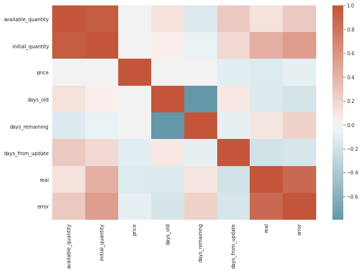

```python
plt.figure(figsize=(12,8))
sns.heatmap(errors_df.corr(),
        xticklabels=errors_df.corr().columns,
        yticklabels=errors_df.corr().columns,
        center=0,
        cmap=sns.diverging_palette(220, 20, as_cmap=True));
```

Verificamos que correlaciona positivamente con el total de ventas

Podriamos seguir haciendo un analisis de inferencia causal con regresiones, significancia estadistica, intervalos de confianza, etc, para determinar las features que explican el error pero voy a optar por dejarlo aca ya que nuestro mayor problema es la asimetria en la distribucion de ventas.